# Short report on campaign 07

08/01/2025 - 04/02/2025

*Last update: 10/09/2025*

## Introduction

The collection of field data is an important element of the HydroCORE project. It allows to make an assessment of the state of the Paute river system and to identify patterns in both space and time. It is expected that these conditions change along the path of the Paute river due to a variety of human and natural influences. For instance, the city of Cuenca is situated in the upstream part of the basin, while two reservoirs are present in the downstream part prior to entering the Amazon region.

To characterise the Paute river system, the HydroCORE project foresees a total of eight sampling campaigns over a period of two years. Abiotic conditions are recorded every three months and supplemented with the collection of macroinvertebrates every six months. At the spatial level, the project aims to include 20 reservoir sites and 30 river sites (totaling 50 sampling sites). These also include sites that are part of a reference system in which no artificial reservoirs are present, being the Jubones river system.

The seventh sampling campaign was performed from 08 January 2025 until 04 February 2025. During this period, a total of 54 sampling sites were visited. The results of the abiotic analyses performed both *on-site* (observations of the field conditions, probe readings) as *off-site* (nutrient analyses) are reported here in a concise manner. More results (e.g., macroinvertebrate samples) will be added later.

## Map of the sampling sites

A total of 54 sampling sites were visited and distributed as follows: (1) 20 river sites, (2) 23 reservoir sites, and (3) 11 reference system sites. The majority of the river sites (*N* = 13) is located upstream of the two reservoirs, while the majority of the reservoir sites (*N* = 17) is located in the largest reservoir (called Mazar). Relatively few reservoir sites (*N* = 6) were visited in the smaller reservoir (called Amaluza) due to accessibility reasons. There are hardly roads leading to the reservoir due to the steep mountains and a large fraction of the water surface is overcrowded by water hyacinth (*E. crassipes*). The map shows where the sampling sites are situated:

[interactive chart not shown]

Figure 1: Map of the sampling locations.

## Physicochemical conditions

At every sampling site, a series of water quality parameters was recorded. In addition, water samples were collected in plastic bottles for nutrient analysis in the lab at UCuenca. Within this section, the results of these analyses are presented in a concise manner and further explored through principal component analysis and hierarchical clustering. Through this exploration, similarities and dissimilarities between sampling sites can be observed.

### Statistical summary

A first step in the data exploration is looking at the characteristic statistics of the considered variables. This provides an idea of the range of the obtained values and indicates if (and where) data is missing. For this overview, a distinction is made between the parameters measured *on-site* and *off-site*.

In addition, Table 1 also contains a summary of the parameters that were measured *off-site*. Nutrient concentrations below the quantification limit were replaced by the quantification limit (*worst-case approach*), resulting in similar values for both the minimum first quartile for most nutrients. The highest nutrient levels were 1.65 mg/L nitrate-nitrogen, 0.15 mg/L nitrite-nitrogen, 1.07 mg/L ammonium-nitrogen, 2.13 mg/L total nitrogen, 0.13 mg/L orthophosphate-phosphorus, and 1.30 mg/L total phosphorus.

Table 1: Summary of the on- and off-site variables

|  | Min | Q1 | Median | Q3 | Max | Mean | SD | #NA |
| --- | --- | --- | --- | --- | --- | --- | --- | --- |
| Altitude [m a.s.l.] | 915.00 | 1989.00 | 2145.00 | 2223.50 | 3469.00 | 2107.02 | 498.25 | 0 |
| Distance | 0.35 | 32.35 | 52.16 | 69.06 | 143.08 | 57.98 | 36.16 | 0 |
| Temperature [oC] | 9.68 | 15.32 | 16.22 | 20.00 | 22.51 | 16.97 | 2.76 | 0 |
| pH [-] | 5.34 | 6.82 | 7.32 | 7.92 | 8.65 | 7.35 | 0.67 | 0 |
| Conductivity [mS/cm] | 0.03 | 0.11 | 0.17 | 0.21 | 0.67 | 0.17 | 0.09 | 0 |
| Salinity [ppt] | 0.00 | 0.05 | 0.10 | 0.10 | 0.20 | 0.08 | 0.05 | 0 |
| Oxygen saturation [%] | 75.30 | 91.10 | 105.10 | 117.75 | 142.60 | 104.97 | 18.01 | 0 |
| Oxygen [mg/L] | 7.11 | 8.77 | 10.04 | 10.71 | 13.58 | 9.82 | 1.42 | 0 |
| Total dissolved solids [g/L] | 0.02 | 0.07 | 0.11 | 0.14 | 89.50 | 1.70 | 11.95 | 0 |
| Oxidation reduction potential [ORPmV] | 217.00 | 276.00 | 302.50 | 331.50 | 363.00 | 302.93 | 34.43 | 0 |
| Turbidity [NTU] | 1.20 | 3.10 | 6.20 | 18.60 | 749.00 | 58.79 | 147.79 | 3 |
| Chlorophyll a [ug/L] | 6.00 | 30.73 | 69.19 | 132.63 | 259.97 | 84.44 | 64.62 | 0 |
| Average velocity [m/s] | 0.00 | 0.00 | 0.07 | 0.38 | 0.84 | 0.20 | 0.23 | 3 |
| TOC [mg/L] | 1.33 | 3.52 | 3.86 | 5.61 | 12.22 | 4.61 | 2.25 | 4 |
| TIC [mg/L] | 2.69 | 8.31 | 9.63 | 10.60 | 17.32 | 9.62 | 2.99 | 2 |
| Total carbon [mg/L] | 4.44 | 12.04 | 13.70 | 17.18 | 22.81 | 14.06 | 3.94 | 2 |
| Nitrate-N [mg/L] | 0.50 | 0.50 | 0.55 | 1.37 | 1.65 | 0.83 | 0.44 | 2 |
| Nitrite-N [mg/L] | 0.00 | 0.00 | 0.02 | 0.03 | 0.15 | 0.03 | 0.04 | 2 |
| Ammonium-N [mg/L] | 0.00 | 0.00 | 0.00 | 0.03 | 1.07 | 0.08 | 0.21 | 2 |
| Orthophosphate-P [mg/L] | 0.00 | 0.00 | 0.01 | 0.06 | 0.13 | 0.03 | 0.04 | 2 |
| Total-N [mg/L] | 0.50 | 0.50 | 0.96 | 1.78 | 2.13 | 1.19 | 0.60 | 2 |
| Total-P [mg/L] | 0.00 | 0.03 | 0.05 | 0.19 | 1.30 | 0.15 | 0.24 | 2 |

### Correlation analysis

The different variables of the previous sections were used as a basis for a correlation analysis (see Figure 2). From this analysis, it is clear that some variables are more correlated than others (as is expected). Salinity and conductivity show a higher-than-average correlation as they more or less reflect the amount of dissolved chemicals in the water column. Also the different nutrients display a higher correlation, especially regarding ammonium-nitrogen and nitrite-nitrogen. Nitrate-nitrogen showed a strong correlation with total-nitrogen, potentially due to the relatively low nitrogen concentrations and the relatively high detection limit of the nitrate analysis (which is also used for detecting total-nitrogen).

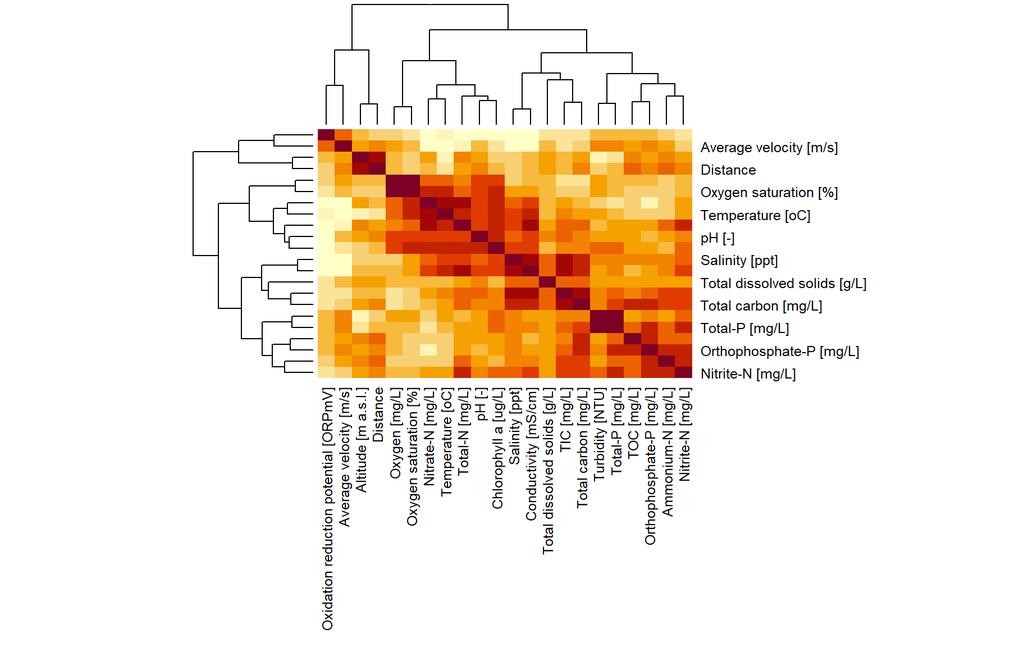

Figure 2: Correlation analysis of the various variables.

### Principal component analysis

From previous sections it is clear that various water quality parameters were assessed in the selected sampling sites. These parameters can be analysed individually to identify (dis)similarities between sampling sites, though that will lead to an overly extensive list of observations. As an alternative, dimensionality reduction can be applied on the data by extracting the most informative patterns and representing them as part of a new set of variables. Principal component analysis (PCA) allows to perform such a dimensionality reduction and shows that the first component is mostly determined by the flow and some presence of pollution (conductivity, total-N). The second principal component is more determined by altitude and individual nutrient ions. This contrasts with the findings of some of the previous campaigns.

The PCA shows that there is no clear clustering of all sampling sites (see Figure 3), which is partially in line with the observed nutrient levels (see Table 1). Sites that showed discrepancy from the majority of the sites included the Cuenca (code ‘CU’) and Paute river (code ‘PA’, locations 01-03), displaying relatively higher nutrient levels. Also, locations downstream in the Paute river (code ‘PA’, locations 08-09) show a clear difference, mostly due to the relatively high oxygen levels that were observed in combination with being situated at a lower altitude.

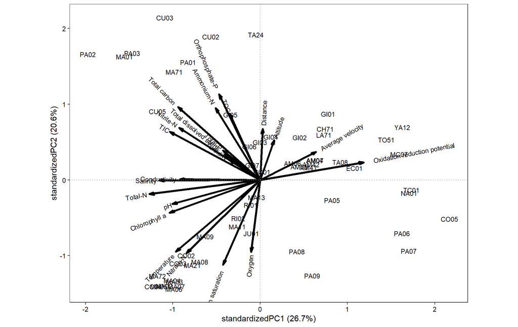

Figure 3: PCA of the physicochemical data.

### Supervised clustering

In addition to the unsupervised analysis provided by PCA, a supervised cluster analysis can be performed to identify (dis)similarities between sampling sites. These (dis)similarities can be calculated through distances, with the Euclidean distance being the most frequently used. Subsequently, clusters are created based on these distances by using a specific linkage technique. Here, Euclidean distances and a complete linkage is being used.

The resulting hierarchical tree displays the closeness of the different sampling sites and shows that spatially close sites do not always cluster together (see Figure 4). Some closely situated sites do cluster together (e.g., RI01/02, GI03/04, MA03/04), while others end up further away in the tree (e.g., PA01/02, GI02/03). Some overlap with the PCA result can also be seen, including the similarity of the sites located upstream from the city of Cuenca (i.e. MC07, TA08, TO51, and YA12).

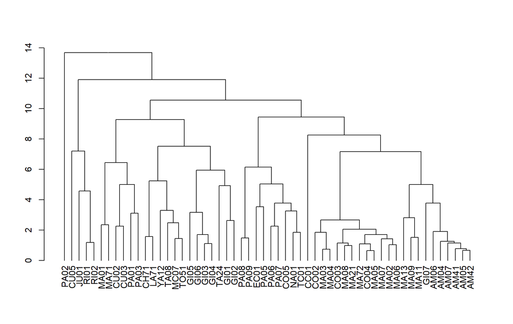

Figure 4: Hierarchical clustering of the sample sites.

## Greenhouse gases

Aside from the abovementioned physicochemical conditions, additional samples were collected to determine (1) the presence of greenhouse gases in a dissolved state within the water column and (2) the emission of greenhouse gases to the atmosphere. Samples were collected in 12 mL glass vials that were pre-rinsed with Helium and subsequently analysed at ETH Zürich. Within this section, the results of these analyses are presented in a concise manner and further explored through principal component analysis and hierarchical clustering. Through this exploration, similarities and dissimilarities between sampling sites can be observed.

### Statistical summary

Similar to the section on the physicochemical conditions, we start with a look at the characteristic statistics of the considered variables. For this overview, a distinction is made between dissolved greenhouse gases and the calculated emissions.

An overall summary is given in Table 2, showing that the level of carbon dioxide in the water column ranged from 27.14 µM up to 212.52 µM, averaging at 63.40 µM (SD = 41.68 µM). Methane levels ranged from 0.07 µM up to 1.76 µM and averaged at 0.31 µM (SD = 0.41 µM). Nitrous oxide levels showed to be relatively uniform and clearly lower than the carbon-based gases.

In addition, Table 2 also contains a summary of the emitted greenhouse gases. Especially interesting here is the negative flux for carbon dioxide (at -1392 mg/m²/d), suggesting a local net uptake of carbon dioxide. Also the maximum emission rate for both carbon dioxide (9635 mg/m²/d) and methane (97 mg/m²/d) are worth mentioning, though the former might be caused by ebullition taking place right under the collecting chamber.

Table 2: Summary of the dissolved and emitted greenhouse gases.

|  | Min | Q1 | Median | Q3 | Max | Mean | SD | #NA |
| --- | --- | --- | --- | --- | --- | --- | --- | --- |
| Nitrous oxide [uM] | 0.02 | 0.02 | 0.02 | 0.03 | 0.06 | 0.03 | 0.01 | 0 |
| Methane [uM] | 0.07 | 0.08 | 0.11 | 0.29 | 1.76 | 0.31 | 0.41 | 0 |
| Carbon dioxide [uM] | 27.14 | 36.38 | 47.22 | 71.61 | 212.52 | 63.40 | 41.68 | 0 |
| Nitrous oxide [mg/m²/d] | -0.05 | 0.04 | 0.13 | 0.31 | 2.90 | 0.36 | 0.67 | 17 |
| Carbon dioxide [mg/m²/d] | -1391.84 | -228.89 | 200.12 | 1098.96 | 9634.87 | 964.19 | 2235.54 | 12 |
| Methane [mg/m²/d] | 0.03 | 0.35 | 1.26 | 9.88 | 96.83 | 12.38 | 25.28 | 8 |

### Correlation analysis

The different variables of the previous sections were used as a basis for a correlation analysis (see Figure 5). As is expected, strong correlations are observed between the dissolved and emitted quantities of methane, while similar correlations are not as unique for the oxygen-based gases. Emitted nitrous oxide displayed a clear correlation with the emitted carbon dioxide, while the dissolved amount of nitrous oxide showed a clear correlation with the dissolved amount of carbon dioxide.

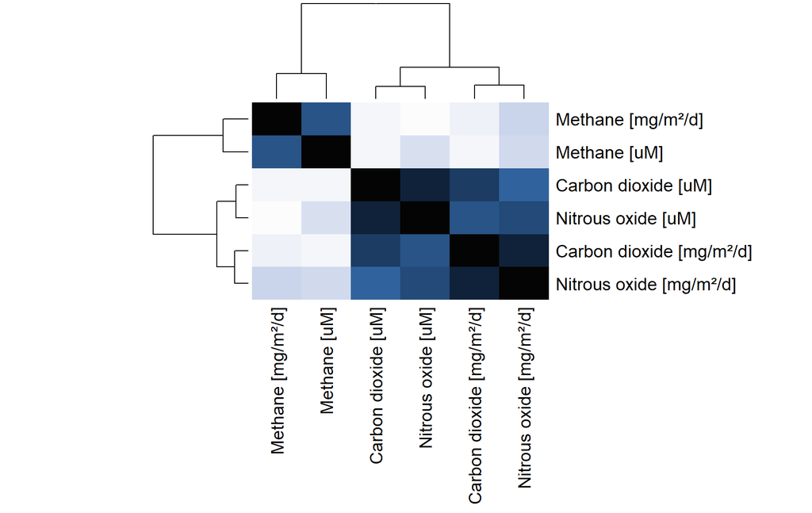

Figure 5: Correlation analysis of the greenhouse gases.

### Principal component analysis

In alignment with the physicochemical conditions, dimensionality reduction can be applied. Principal component analysis (PCA) shows that the first component is mostly determined by the oxygen-based greenhouse gases and that the second principal component is additionally determined by methane.

The PCA shows that the majority of sampling sites cluster together (see Figure 6). Sites that showed discrepancy from the majority of the sites included the Cuenca (code ‘CU’ and ‘PA01/02/03’) river, the Mazar (code ‘MA’) reservoir and the Amaluza (code ‘AM’) reservoir. The sites in the Amaluza reservoir showed to be highly different at the level of the oxygen-based gases, while the more upstream sites (Mazar and Cuenca) show higher values for methane.

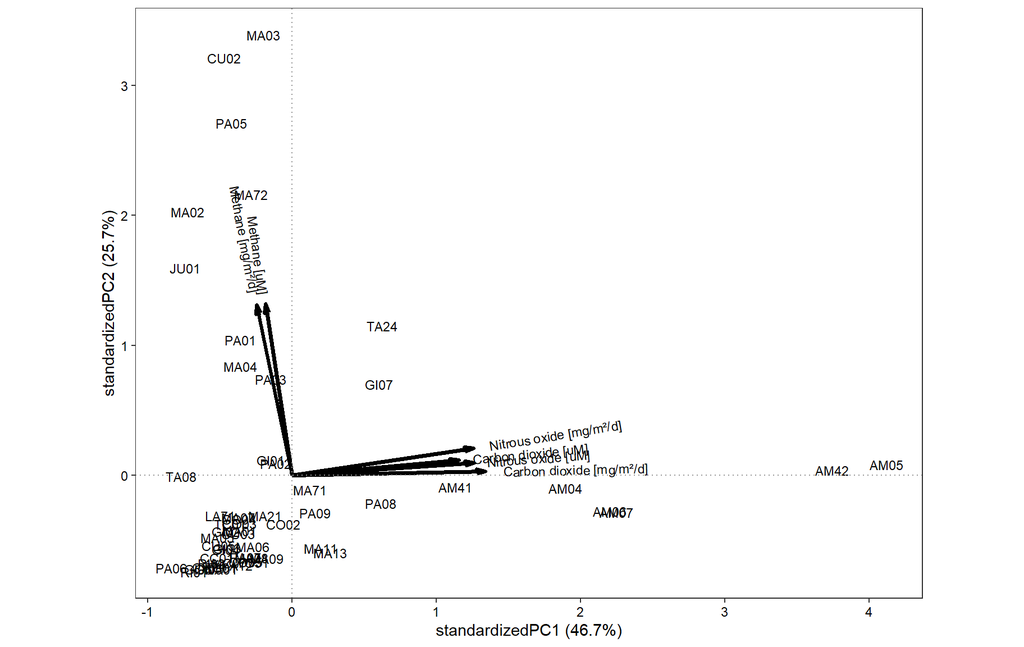

Figure 6: PCA of the greenhouse gas data.

### Supervised clustering

In addition to the unsupervised analysis provided by PCA, the supervised cluster analysis displays the closeness of the different sampling sites and shows that spatially close sites do not always cluster together (see Figure 7). Some closely situated sites do cluster together (e.g., GI03/04, CO02/03), while others end up further away in the tree (e.g., MA04/05, PA01/02, TA08/24). Some overlap with the PCA result can also be seen, especially relating to the clustering of the Amaluza sites.

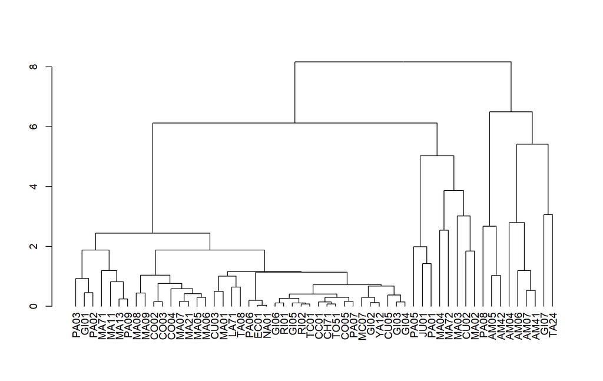

Figure 7: Hierarchical clustering of the sample sites.

## Summary

A total of 54 sampling sites were selected and assessed for a variety of water quality parameters and a set of greenhouse gases. Nutrient levels were relatively low when compared to previous campaigns, which is likely caused by the normal to extensive rainfall activities prior to and during the sampling campaign. Several sampling sites seem to display different conditions, most of them located near or downstream of urbanisation. For example, the Cuenca (CU02/03) and Paute (PA01/02) sites are situated downstream of Cuenca, while the Giron sites are situated in (GI03) and downstream (GI04) of the town of Giron. Similarly, gas concentrations and emissions seemed to be lower than previous campaigns and still allowed for some degree of clustering of the Amaluza sites (relatively high oxygen-based gases).

## Acknowledgement

We would like to thank K.P. Ramirez Pozo, D.V. Tigre Remache, M.E. Carpio Moreno, and R.M. Perez Sucuzhañay for their help in collecting the samples in the field as well as their subsequent processing in the lab. We also thank D.G. Zuñiga Villegas for providing us with the necessary transport and M. Barthel for the analyses of the greenhouse gas samples.

## Reference

Van Echelpoel, W. (2025). *Short report on campaign 07*. HydroCORE project. Online: https://wvechelp.github.io/HydroCORE/Reports/ShortReportCampaign07.html

Read more on the [HydroCORE webpage](https://wvechelp.github.io/HydroCORE/).